# Maternal Health Risks Classification KNN and Decision Trees

Rex Manglicmot

## Status: Continuing Working Document

Hi everyone. I’m continuing building my data analysis and R skills. As such, I would love feedback to better improve this project via rexmanglicmot@gmail.com. Any mistakes and misrepresentation of the data are my own.

Things Need to Do/Questions:

- provide more context on what is “maternal health risks” according to the site
- rewrite intro and cite sources
- state objective of this project more convincingly
- provide more concepts/theory about KNN and Decision Trees in each of their sections
- check grammar
- provide more insights into the models
- check validation tests for the moels
- get feedback and incorporate

## Introduction

Maternal health risks has increased since the medieval days. However, there is still a need to understand the underlying factors that contribute to women health includings metrics such as age and blood sugar levels over various age groups.

Based on UCI’s Repository below are the metrics: 1. Age 2. Systolic BP (blood pressure) 3. Diastolic BP (blood pressure) 4. Blood Sugar 5. Body Temp 6. Heart Rate 7. Risk Level

## Loading the Libraries

```r
#load libraries
library(tidyverse)
library(corrplot)
library(RColorBrewer)
library(gghalves)
#library(GGally)
library(class)
library(ggridges)
library(party)
library(partykit)
library(rpart)
library(rpart.plot)
```

## Loading the Data

```r
#load data
data <- read.csv('Maternal Health Risk Data Set.csv')
```

## Cleaning the Data

```r
#print first few rows of the data
head(data,n=10)
```

|  | Age | SystolicBP | DiastolicBP | BS | BodyTemp | HeartRate | RiskLevel |
| --- | --- | --- | --- | --- | --- | --- | --- |
| 1 | 25 | 130 | 80 | 15.00 | 98 | 86 | high risk |
| 2 | 35 | 140 | 90 | 13.00 | 98 | 70 | high risk |
| 3 | 29 | 90 | 70 | 8.00 | 100 | 80 | high risk |
| 4 | 30 | 140 | 85 | 7.00 | 98 | 70 | high risk |
| 5 | 35 | 120 | 60 | 6.10 | 98 | 76 | low risk |
| 6 | 23 | 140 | 80 | 7.01 | 98 | 70 | high risk |
| 7 | 23 | 130 | 70 | 7.01 | 98 | 78 | mid risk |
| 8 | 35 | 85 | 60 | 11.00 | 102 | 86 | high risk |
| 9 | 32 | 120 | 90 | 6.90 | 98 | 70 | mid risk |
| 10 | 42 | 130 | 80 | 18.00 | 98 | 70 | high risk |

```r
#Change BS to BloodSugar for better understanding
colnames(data)[4] <-'BloodSugar'

#glimpse data
glimpse(data)
```

```
Rows: 1,014
Columns: 7
$ Age         <int> 25, 35, 29, 30, 35, 23, 23, 35, 32, 42, 23, 19, 25, 20, 48, 15, 50, 25, 30, 10, 40, 50, 21, 18, 21, 16, 19,…
$ SystolicBP  <int> 130, 140, 90, 140, 120, 140, 130, 85, 120, 130, 90, 120, 110, 120, 120, 120, 140, 140, 120, 70, 140, 140, 9…
$ DiastolicBP <int> 80, 90, 70, 85, 60, 80, 70, 60, 90, 80, 60, 80, 89, 75, 80, 80, 90, 100, 80, 50, 100, 80, 65, 60, 80, 70, 7…
$ BloodSugar  <dbl> 15.00, 13.00, 8.00, 7.00, 6.10, 7.01, 7.01, 11.00, 6.90, 18.00, 7.01, 7.00, 7.01, 7.01, 11.00, 7.01, 15.00,…
$ BodyTemp    <dbl> 98, 98, 100, 98, 98, 98, 98, 102, 98, 98, 98, 98, 98, 100, 98, 98, 98, 98, 101, 98, 98, 98, 98, 98, 98, 98,…
$ HeartRate   <int> 86, 70, 80, 70, 76, 70, 78, 86, 70, 70, 76, 70, 77, 70, 88, 70, 90, 80, 76, 70, 90, 70, 76, 70, 76, 80, 66,…
$ RiskLevel   <chr> "high risk", "high risk", "high risk", "high risk", "low risk", "high risk", "mid risk", "high risk", "mid …
```

Now, with the relevant libraries are loaded and the dataset variables are clearly understood, next steps are to clean and check for missing values, characters that are unothordox to each of the metrics via R codes below.

```r
#check for  missing data in full dataset
#difficult to do when there are lots of observations
sum(is.na(data))
```

```
[1] 0
```

```r
#double check for missing data via different columns
#again difficult
sum(is.na(data$Age))
```

```
[1] 0
```

Let’s try another method.

```r
#check for missing data for each variable column using sum
#output is 0 for all columns
colSums(is.na(data))
```

```
        Age  SystolicBP DiastolicBP  BloodSugar    BodyTemp   HeartRate   RiskLevel
          0           0           0           0           0           0           0
```

```r
#find location of missing data, if any
which(is.na(data))
```

```
integer(0)
```

```r
#get percentage of missing data in dataset
mean(is.na(data))
```

```
[1] 0
```

The dataset is cleaned and tidy. Next steps are to do EDA.

## Exploratory Data Analysis

```r
#Summary statistics of each of the variables
str(data)
```

```
'data.frame':   1014 obs. of  7 variables:
 $ Age        : int  25 35 29 30 35 23 23 35 32 42 ...
 $ SystolicBP : int  130 140 90 140 120 140 130 85 120 130 ...
 $ DiastolicBP: int  80 90 70 85 60 80 70 60 90 80 ...
 $ BloodSugar : num  15 13 8 7 6.1 7.01 7.01 11 6.9 18 ...
 $ BodyTemp   : num  98 98 100 98 98 98 98 102 98 98 ...
 $ HeartRate  : int  86 70 80 70 76 70 78 86 70 70 ...
 $ RiskLevel  : chr  "high risk" "high risk" "high risk" "high risk" ...
```

```r
#Structure of data without the RiskLevel variable because it is a character
summary(data[-7])
```

```
      Age          SystolicBP     DiastolicBP       BloodSugar        BodyTemp        HeartRate
 Min.   :10.00   Min.   : 70.0   Min.   : 49.00   Min.   : 6.000   Min.   : 98.00   Min.   : 7.0
 1st Qu.:19.00   1st Qu.:100.0   1st Qu.: 65.00   1st Qu.: 6.900   1st Qu.: 98.00   1st Qu.:70.0
 Median :26.00   Median :120.0   Median : 80.00   Median : 7.500   Median : 98.00   Median :76.0
 Mean   :29.87   Mean   :113.2   Mean   : 76.46   Mean   : 8.726   Mean   : 98.67   Mean   :74.3
 3rd Qu.:39.00   3rd Qu.:120.0   3rd Qu.: 90.00   3rd Qu.: 8.000   3rd Qu.: 98.00   3rd Qu.:80.0
 Max.   :70.00   Max.   :160.0   Max.   :100.00   Max.   :19.000   Max.   :103.00   Max.   :90.0
```

Age is interesing because the min and max are 10 and 70, respectively. Generally, as the age increases, there tends to be more complications and thus, this is a variable that I will focus on.

But first, let’s just focus on the RiskLevel variable and see what values are present and each of their count, and visualize the count via a barchart.

```r
#what are the of categories within Risk Level
distinct(data,RiskLevel)
```

| RiskLevel |
| --- |
| high risk |
| low risk |
| mid risk |

```r
#sum categories within Risk Level
data %>%
  group_by(RiskLevel) %>%
  count()
```

| RiskLevel | n |
| --- | --- |
| high risk | 272 |
| low risk | 406 |
| mid risk | 336 |

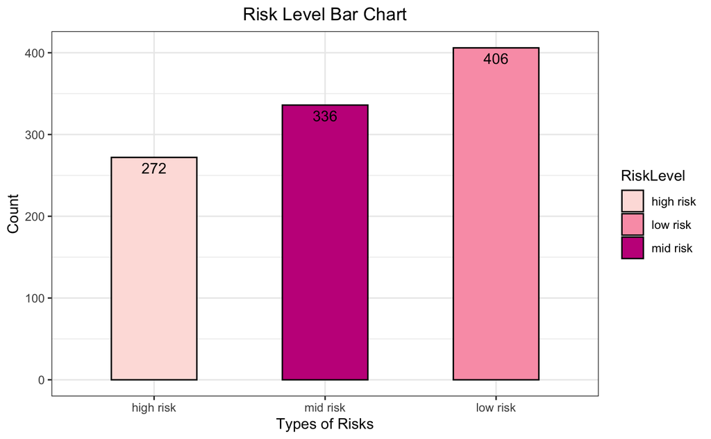

```r
#Visualize count the number of categories within Risk Level
ggplot(data, aes(x=RiskLevel, fill=RiskLevel)) +
  geom_bar(width=.5, color ='black') +
  labs(title = 'Risk Level Bar Chart',
    x= 'Types of Risks',
    y= "Count") +
  scale_fill_brewer(palette = 'RdPu') +
  theme_bw() +
  theme(plot.title = element_text(hjust = 0.5)) +
  scale_x_discrete(limits=c('high risk', 'mid risk', 'low risk')) +
  geom_text(aes(label = ..count..), stat = "count", vjust = 1.5,
            color = "black")
```

From the above code and bar chart we see that there are three different types of Risk Levels associated with this dataset that the author define as; high, mid, and low risks. From the bar chart above we conclude that the counts are high < mid < low.

Now, let’s focus on exploring the Age variable.

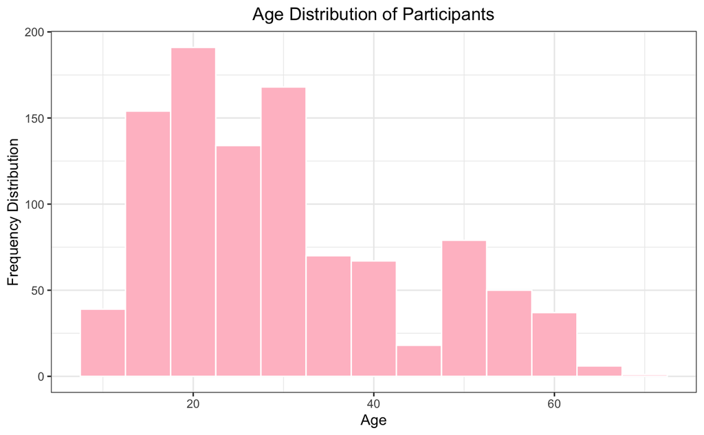

```r
#Histogram of Ages
#it looks bimodal
ggplot(data, aes(Age)) +
  geom_histogram(binwidth=5, fill = 'pink',
                 color = 'white') +
  theme_bw() +
  ggtitle('Age Distribution of Participants') +
  labs(y = 'Frequency Distribution') +
  theme(plot.title = element_text(hjust = 0.5))
```

A histogram is a means to show the frequency distribution as observations are put into designated bins.

Some insights by ,anipulating the bindwidth, I find the shape of the distribution is *bimodal* signifying that there could be two groups I could possible take a look at. The first and second peak is Age~20 and Age~50. A possible path is that I could break up the dataset into two parts based on the peaks (modes) and each art would have its own summary statistics.

But for now, let’s continue with the EDA within age variable.

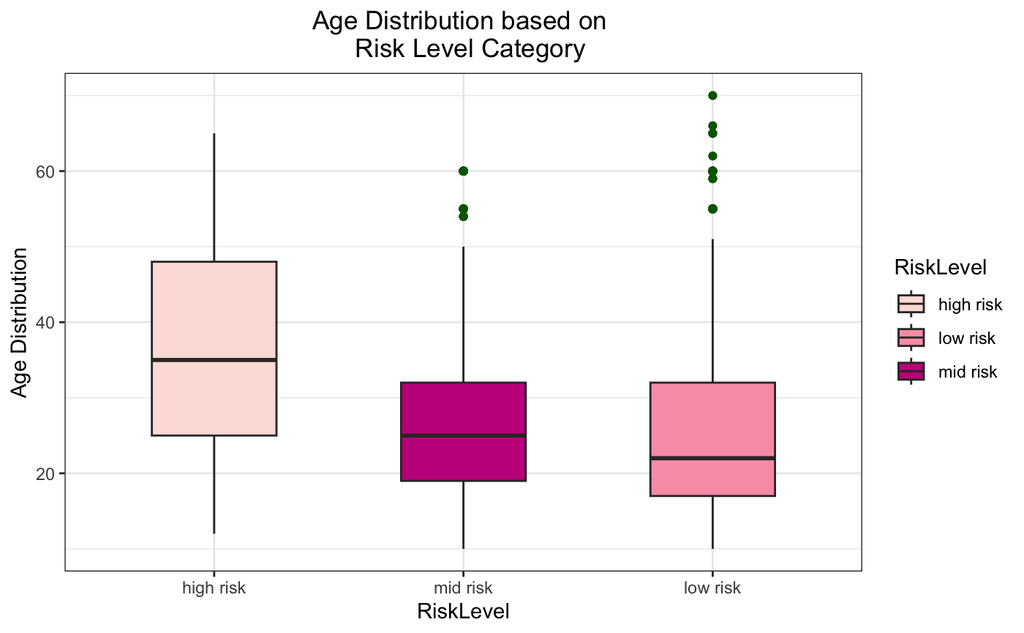

```r
ggplot(data, aes(x=RiskLevel, y=Age, fill=RiskLevel)) +
  geom_boxplot(width=0.5,
               outlier.color='darkgreen') +
  theme_bw() +
  scale_fill_brewer(palette = 'RdPu') +
  scale_x_discrete(limits=c('high risk', 'mid risk', 'low risk')) +
  ggtitle('Age Distribution based on
  Risk Level Category') +
  labs(y = 'Age Distribution') +
  theme(plot.title = element_text(hjust = 0.5))
```

Another way is see the distribution is via boxplot. Like the summary() function this plot shows the min, Q1, median, Q3, and max. But unlike that function, the boxplot helps us visualize the data and point out the outliers, which are not shown in the summary table, as shown as green dots here.

Some insights from this graph is that shape of the boxes and whisker lengths are almost identical between the mid and low risk categories. This means that based on this dataset’s Age, it is difficult to distinguish between the two. In addition, both have outliers that are above the age, 50. The outliers skews the data, and in this case, pulls the mid and low risk categories upwards to the higher age range. The best way to visualize this is via a density plot, which we will go over in the next section.

The key insight is that of the high risk category boxplot. The “box” which contains 50% of the data is much bigger in comparison to mid and low risk. What this means is that women between the ages of roughly 22-48 could possibly lie within a high risk category of maternal risks. Extrapolating further, the median is also much higher, age~35. What this prompts is that indicating that are women in the mid thirties could possibly lie within a high risk category. This is an interesting finding.

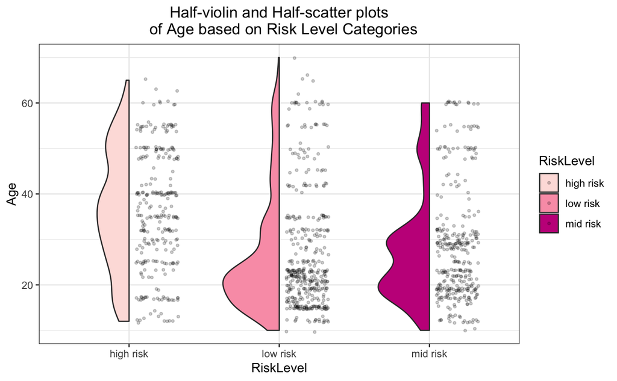

```r
ggplot(data, aes(x=RiskLevel, y=Age, fill=RiskLevel)) +
  geom_half_violin() +
  geom_half_point(alpha=0.2, color='black',
                  size=0.8, position = 'dodge') +
  scale_fill_brewer(palette = 'RdPu') +
  theme_bw() +
  labs(title = 'Half-violin and Half-scatter plots
  of Age based on Risk Level Categories') +
  theme(plot.title = element_text(hjust = 0.5))
```

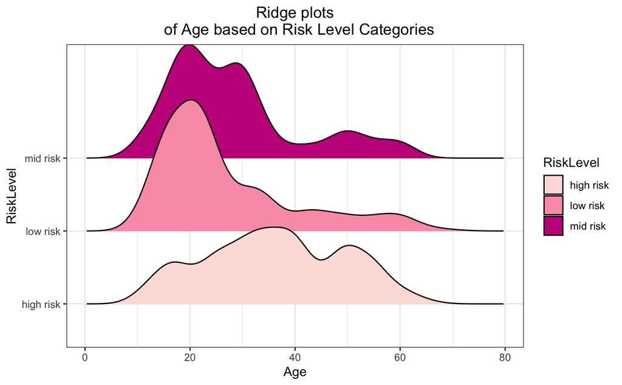

```r
ggplot(data, aes(x=Age, y=RiskLevel, fill=RiskLevel)) +
  geom_density_ridges_gradient() +
    scale_fill_brewer(palette = 'RdPu') +
  theme_bw() +
    labs(title = 'Ridge plots
  of Age based on Risk Level Categories') +
  theme(plot.title = element_text(hjust = 0.5))
```

To continue with the Age variable, I wanted to broaden my R skills by using different visualizations the programming language offers. To further compliment the boxplot, I wanted to use gghalves and create a half-violin and half-scatter plot.

Now, let’s move on to a tradtional appraoch to see if there are any correlations between the variables, excluding RiskLevel. One such approach is a correlation matrix that conventiently describes the data, by looking at the raw data.

```r
#Create data without last variable that contained chr
# -c(7) corresponds to the last variable
corrplot_data <-data[,-c(7)]

#Check to see if RiskLevel is deleted
names(corrplot_data)
```

```
[1] "Age"         "SystolicBP"  "DiastolicBP" "BloodSugar"  "BodyTemp"    "HeartRate"
```

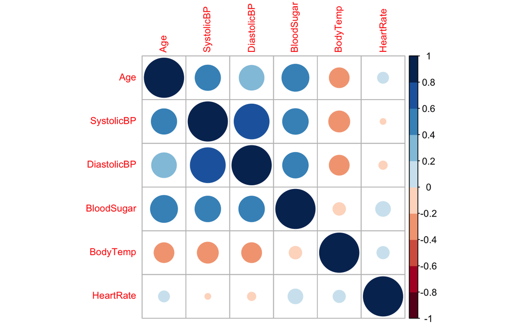

```r
#Simple Corrplot
corrplot(cor(corrplot_data),
         col=brewer.pal(n=10, name='RdBu'),
         tl.cex = 0.8)
```

## Modeling: K-Neighrest Neighbors

Now, let’s see if the dataset metrics can be used to predict whether a person is high, mid, or low risk. The method I’am using is K Nearest Neighbors, a distance algorithmn. In short, it will classify an unknown observation, with it’s known metrics, to a category based on it’s nearest neigbors

The data will be split into the traditional 80/20 split that will split 80% of the data into the training set and 20% of the data into the testing set. It is important to note that we never want to train iwth our testing data.

```r
#see structure of the dataset
str(data)
```

```
'data.frame':   1014 obs. of  7 variables:
 $ Age        : int  25 35 29 30 35 23 23 35 32 42 ...
 $ SystolicBP : int  130 140 90 140 120 140 130 85 120 130 ...
 $ DiastolicBP: int  80 90 70 85 60 80 70 60 90 80 ...
 $ BloodSugar : num  15 13 8 7 6.1 7.01 7.01 11 6.9 18 ...
 $ BodyTemp   : num  98 98 100 98 98 98 98 102 98 98 ...
 $ HeartRate  : int  86 70 80 70 76 70 78 86 70 70 ...
 $ RiskLevel  : chr  "high risk" "high risk" "high risk" "high risk" ...
```

```r
#make a copy of the orginal dataset
data2 <-data
```

We see that dependent variable, RiskLevel, is a character and for purposes of KNN, RiskLevel needs to converted into a factor.

```r
#convert the RiskLevel column, our target, into a factor
data2$RiskLevel <- as.factor(data2$RiskLevel)
```

Now we need to normalize the 6 remaining metrics, but first in order to be more efficient, let’s write a function that will iterate over each variable column instead of assigned values witin a variable to an object and piecing it together in another dataframe. Again, we are not interested in the RiskLevel, so I will disregard that variable column when I code the lapply.

```r
#need to normalize data with a range between 0 and 1
#create a function to iterate for each variable column
data_norm <- function (x) {
  ((x-min(x))/ (max(x)- min(x)))
}
#create the normalize data
#lapply will iterate over each of the variables and store it into a
#dataframe object except for target variable, RiskLevel
data3 <- as.data.frame(lapply(data2[,-7], data_norm))
```

Let’s compare the the summary statistics of data2 (pre-normalizaiton) to data3 (post-normalization).

```r
#check to see if ALL values range from 0 to 1
#important to do this before doing KNN
summary(data2[-7])
```

```
      Age          SystolicBP     DiastolicBP       BloodSugar        BodyTemp        HeartRate
 Min.   :10.00   Min.   : 70.0   Min.   : 49.00   Min.   : 6.000   Min.   : 98.00   Min.   : 7.0
 1st Qu.:19.00   1st Qu.:100.0   1st Qu.: 65.00   1st Qu.: 6.900   1st Qu.: 98.00   1st Qu.:70.0
 Median :26.00   Median :120.0   Median : 80.00   Median : 7.500   Median : 98.00   Median :76.0
 Mean   :29.87   Mean   :113.2   Mean   : 76.46   Mean   : 8.726   Mean   : 98.67   Mean   :74.3
 3rd Qu.:39.00   3rd Qu.:120.0   3rd Qu.: 90.00   3rd Qu.: 8.000   3rd Qu.: 98.00   3rd Qu.:80.0
 Max.   :70.00   Max.   :160.0   Max.   :100.00   Max.   :19.000   Max.   :103.00   Max.   :90.0
```

```r
summary(data3)
```

```
      Age           SystolicBP      DiastolicBP       BloodSugar         BodyTemp       HeartRate
 Min.   :0.0000   Min.   :0.0000   Min.   :0.0000   Min.   :0.00000   Min.   :0.000   Min.   :0.0000
 1st Qu.:0.1500   1st Qu.:0.3333   1st Qu.:0.3137   1st Qu.:0.06923   1st Qu.:0.000   1st Qu.:0.7590
 Median :0.2667   Median :0.5556   Median :0.6078   Median :0.11538   Median :0.000   Median :0.8313
 Mean   :0.3312   Mean   :0.4800   Mean   :0.5384   Mean   :0.20969   Mean   :0.133   Mean   :0.8109
 3rd Qu.:0.4833   3rd Qu.:0.5556   3rd Qu.:0.8039   3rd Qu.:0.15385   3rd Qu.:0.000   3rd Qu.:0.8795
 Max.   :1.0000   Max.   :1.0000   Max.   :1.0000   Max.   :1.00000   Max.   :1.000   Max.   :1.0000
```

data 3 is summarized and ready to go into the KNN model.

Let’s do a pre-check when splitting the data into a 80/20 split before actually doing the split.

```r
#create split concept
a <- .8*1014
b <- .2*1014
a+b
```

```
[1] 1014
```

```r
811+203
```

```
[1] 1014
```